# FrailMaleMortalityABSouth

jim (and jesse, soon)

Frail males are familiar to students of biology (less so, to economists and historians). A wide range of research [^1] demonstrates that tough times during pregnancy skews the sex ratio in live births, and that tough times in infancy skews the infant sex ratio. So Steckel’s picture of slave pregnancy and a dreadful childhood in the AB South points to the proposition that slave births would have been skewed toward females. We can test this by comparing sex ratio among the young in slave and free populations in the AB South.

To advance Steckel’s view, we pose the null hypothesis that the southern slave population’s SR1 is the same as the white population’s, against the alternative that the slave SR1 is lower. Point estimate is -9.5%

To refute Steckel’s view, we pose the null hypothesis that the slave SR1 is at least 5% points below the white SR1, against the alternative that the slave SR1 is closer to the white value.

Frail males are familiar. A wide range of research demonstrates that tough times during pregnancy skews the sex ratio in live births. So Steckel’s picture of slave pregnancy in the AB South points to the proposition that slave births would have been skewed toward females. We can test this by comparing sex ratio among the young in slave and free populations in the AB Sotuh.

### Bio-social mechanisms and evidence

#### Fetal Mortality

Relative to females, the frail males are culled in utero by maternal stress and malnutrition. With stillbirth rates on the order of 13% (like early 20th C black populations), the natural SR of 1.05 will be pulled down

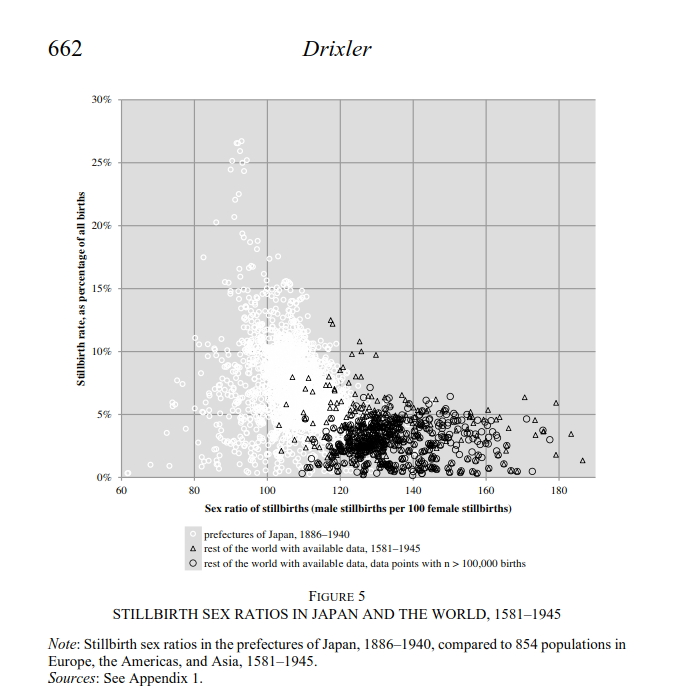

Take Drixler evidence : SR in SB of 1.3 or more, and rates of SB relative to living, to see 1.053 pulled down to 1.026[^2].

Potentially relevant to stillbirth effects, Sweden 1999-2000 infant mortality among preemies (born at 23-24 weeks) was 55% for males and 32% for females. That in [Ingemarsson] (https://jimirwin.github.io/Dreadful/lit.html#Ingemarsson), who also cites Hassold et al for 1.32 sex ratio in chromosonally normal spontaneous abortions.

Hui-Lung et Al. ([1997 Obstetrics & Gynecology (https://www.sciencedirect.com/science/article/abs/pii/S0029784496003754)] say “Disparity in the crude fetal death rates for blacks and whites is explained almost entirely by differences in birth weight distribution.” (1979: blacks 14.6 **per thousand**, whites 8.2 )

Steckel 1986 EEH p186 wartime famine in Holland reduced birth weight 300g energy supplements during last two trimesters rural Guatemla increased birth weight 120g chronic poor nutrition not a general problem among working slaves short maternal stature [not] an important factor [in slaves’ low birth weight] birth weights of whites exceed blacks in US by ~200g

Alabama 1860 census thinking about how to clarify counting of infants  
Covington Co 8 m 18f I count 8 18 fractional ages … use PUMS for 1 yo? Wow, state-level infant sex ratios for slaves ~95% white >1.05

### A Priori Anti-Steckel

Were slave newborns small enough for the Steckel mortality effect? McIntire, Bloom Et Al birth-weight neonatal mortality risk is at weights below 3rd percentile .03% vs .3% in Dallas TX hospitals in the 1980s https://www.cdc.gov/growthcharts/html_charts/wtageinf.htm

| percentile | male | female |
| --- | --- | --- |
| 3rd | 2355g | 2414g |
| 10th | 2774 | 2747 |
| 50th | 3530 | 3399 |

Planters would have noticed that feeding kids was worthwhile Stulp & Barrett (2014) Indeed, lack of nutrition, particularly protein deficiency, is recognized as one of the main contributors to reduced infant growth in developing countries, and supplementary food programs have been shown to produce clear improvements in growth rates and reduced stunting Edozien, Khan & Waslien, 1976; Beaton & Ghassemi, 1982; Silventoinen, 2003

[LITERATURE](https://jimirwin.github.io/Dreadful/DreadfulLit.html)

#### tasks/tactics

20200512 would be nice to corroborate maternal misery with the SSR of a known population with horrible material conditions Ji: modern mumbai? or Rio (to which Steckel refers) Js: antebellum NE slums are a separate fish to fry

census of india 1891 p64 maybe something? – mention female survive famine more p247 ratio for <1 https://dsal.uchicago.edu/statistics/1876_excel/index.html 1881 India census

[^1]: (bio? medical? social science?)
[^2]: That 1.026 will then be pulled down further by infant mortality which is borne more by the frail male, probably 1.2x as much. So if after the stillbirth culling we have a SR of 1.026, a 30% infant mortality rate will leave infant sex ratio of 0.95. The 1.026 comes from a SR in stillbirths (SB) of say 1.30, which implies male SBR 1.234 times the female, with a 12% rate of SB (low for the dreadful maternity scenario)